# Model Experiments

## 16.4 Shared variance and relative importance

The paper’s three main predictors — the concentration of disadvantage, overall absence and mean KS2 prior attainment — are strongly correlated with one another. That creates a problem for any claim about which of them matters most. A *t*-value in a multiple regression measures how precisely a coefficient is estimated once every other predictor is held constant, so it credits a variable only with the variance it alone explains. Where predictors overlap heavily, that unique portion can be small for all of them, and the ordering of *t*-values need not track the ordering of explanatory importance at all.

This section works the problem from several directions: how far the predictors overlap, what each explains on its own, what happens across every possible combination of them, and how the shared portion looks when it is apportioned formally rather than assigned to whichever variable is credited first. The motivation is to establish whether the paper’s substantive claim — that disadvantage concentration is a weak lever relative to absence — depends on the method used to rank predictors. It does not.

This runs on 12,199 school-years.

### 16.4.1 How far do the predictors overlap?

```r
vd_mat <- cbind(
  `% FSM (log)`   = log(vd_data$PTFSM6CLA1A),
  `% Absence (log)` = log(vd_data$PERCTOT),
  `Mean KS2`      = vd_data$ks2_c
)
round(cor(vd_mat), 3) %>% knitr::kable()
```

Table 2: Pairwise correlations among the three main predictors, on the estimation sample.

|  | % FSM (log) | % Absence (log) | Mean KS2 |
| --- | --- | --- | --- |
| % FSM (log) | 1.000 | 0.467 | -0.690 |
| % Absence (log) | 0.467 | 1.000 | -0.591 |
| Mean KS2 | -0.690 | -0.591 | 1.000 |

```r
vd_vif <- vapply(names(VD_PREDS), function(v) {
  others <- setdiff(names(VD_PREDS), v)
  lhs <- if (v == "ADMPOL_PT") "as.numeric(ADMPOL_PT == 'SEL')" else v
  r2 <- summary(lm(as.formula(paste(lhs, "~", paste(others, collapse = " + "))),
                   data = vd_data))$r.squared
  1 / (1 - r2)
}, numeric(1))

tibble(Predictor = vd_lbl(names(VD_PREDS)), VIF = as.numeric(vd_vif)) %>%
  arrange(desc(VIF)) %>%
  mutate(VIF = sprintf("%.2f", VIF)) %>%
  knitr::kable(align = "lr")
```

Table 3: Variance inflation factors for the full fixed-effect specification, computed from auxiliary regressions of each predictor on all the others.

| Predictor | VIF |
| --- | --- |
| Mean KS2 prior attainment | 3.55 |
| % FSM (disadvantage) | 2.59 |
| Admissions policy | 2.23 |
| % Absence | 1.86 |
| Gorard segregation | 1.56 |
| % EAL | 1.35 |
| Teacher retention | 1.29 |
| Leadership pay % | 1.25 |
| Teacher sickness days | 1.10 |

The three main predictors are substantially correlated, but no variance inflation factor approaches the conventional thresholds of 5 or 10. The models are not unstable; the difficulty is one of attribution rather than estimation. Multicollinearity of this degree does not bias the coefficients or inflate the standard errors to the point of unreliability — it simply means that a large part of the explained variance cannot be assigned to any one predictor on the evidence of the coefficients alone.

### 16.4.2 What each predictor explains on its own

```r
vd_alone <- tibble(
  Predictor = vd_lbl(VD_FOCAL),
  `R² alone` = vapply(VD_FOCAL, \(v) vd_r2(v), numeric(1))
) %>% arrange(desc(`R² alone`))

vd_r2_three <- vd_r2(VD_FOCAL)

vd_alone %>%
  mutate(`R² alone` = sprintf("%.3f", `R² alone`)) %>%
  knitr::kable(align = "lr")
```

Table 4: Each main predictor as the sole regressor. The R-squared values sum to far more than the R-squared of the three together, which is the overlap made visible.

| Predictor | R² alone |
| --- | --- |
| Mean KS2 prior attainment | 0.586 |
| % Absence | 0.498 |
| % FSM (disadvantage) | 0.393 |

Individually the three predictors account for 59%, 50% and 39% of the variation in log Attainment 8. Together they account for 70%, not the 148% that simple addition would give. The difference is variance held in common.

### 16.4.3 Every combination of the three main predictors

```r
vd_sub <- purrr::map_dfr(1:3, function(k) {
  combn(VD_FOCAL, k, simplify = FALSE) %>%
    purrr::map_dfr(function(s) tibble(
      k = k,
      Predictors = paste(vd_lbl(s), collapse = " + "),
      `R²` = vd_r2(s)))
})

vd_sub %>%
  mutate(`R²` = sprintf("%.3f", `R²`)) %>%
  select(`Variables` = k, Predictors, `R²`) %>%
  knitr::kable(align = "clr")
```

| Variables | Predictors | R² |
| --- | --- | --- |
| 1 | % FSM (disadvantage) | 0.393 |
| 1 | % Absence | 0.498 |
| 1 | Mean KS2 prior attainment | 0.586 |
| 2 | % FSM (disadvantage) + % Absence | 0.612 |
| 2 | % FSM (disadvantage) + Mean KS2 prior attainment | 0.605 |
| 2 | % Absence + Mean KS2 prior attainment | 0.685 |
| 3 | % FSM (disadvantage) + % Absence + Mean KS2 prior attainment | 0.696 |

```r
tibble(
  Predictor = vd_lbl(VD_FOCAL),
  `R² alone` = vapply(VD_FOCAL, \(v) vd_r2(v), numeric(1)),
  `R² added last` = vapply(VD_FOCAL,
    \(v) vd_r2(VD_FOCAL) - vd_r2(setdiff(VD_FOCAL, v)), numeric(1))
) %>%
  mutate(Shared = `R² alone` - `R² added last`) %>%
  arrange(desc(`R² alone`)) %>%
  mutate(across(where(is.numeric), \(x) sprintf("%.3f", x))) %>%
  knitr::kable(align = "lrrr")
```

Table 6: What each predictor adds when it enters last, against what it explains on its own. The gap between the two columns is the variance it shares with the other two.

| Predictor | R² alone | R² added last | Shared |
| --- | --- | --- | --- |
| Mean KS2 prior attainment | 0.586 | 0.084 | 0.502 |
| % Absence | 0.498 | 0.091 | 0.407 |
| % FSM (disadvantage) | 0.393 | 0.011 | 0.382 |

The two columns give the two extreme answers to the attribution question. “R² alone” credits a predictor with everything it shares with the others; “R² added last” credits it with none of that. Neither is a defensible ranking on its own, and for these variables the two orderings need not agree.

### 16.4.4 Apportioning the shared variance

The standard resolution is to average over every possible order in which the variables could enter, so that each predictor is credited with the shared variance exactly as often as it is denied it. This is the Shapley value from cooperative game theory (Shapley 1953), known in the regression context as the LMG decomposition after Lindeman, Merenda and Gold (1980) and set out for regression by Grömping (2007). The values below are computed directly over the subset lattice rather than taken from a package; the `relaimpo` package implements the same quantity as `calc.relimp(type = "lmg")` and reproduces these figures to floating-point precision.

```r
vd_shap3 <- vd_shapley(VD_FOCAL)

vd_shap3_tbl <- tibble(
  Predictor = vd_lbl(VD_FOCAL),
  `Shapley R²` = as.numeric(vd_shap3),
  Share = as.numeric(vd_shap3) / sum(vd_shap3)
) %>% arrange(desc(`Shapley R²`))

vd_shap3_tbl %>%
  mutate(`Shapley R²` = sprintf("%.3f", `Shapley R²`),
         Share = sprintf("%.1f%%", 100 * Share)) %>%
  knitr::kable(align = "lrr")
```

Table 7: Shapley (LMG) decomposition of the three-predictor model. Each variable’s contribution is averaged over all six orders of entry, so the shared variance is split rather than assigned arbitrarily.

| Predictor | Shapley R² | Share |
| --- | --- | --- |
| Mean KS2 prior attainment | 0.290 | 41.7% |
| % Absence | 0.249 | 35.8% |
| % FSM (disadvantage) | 0.157 | 22.5% |

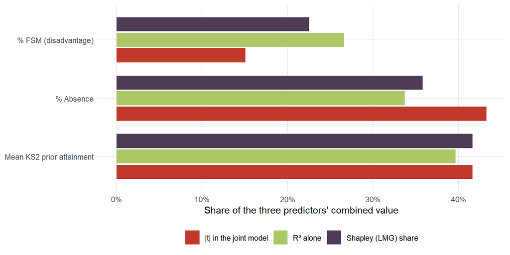

Figure 13: The three main predictors under three different measures of importance. The ordering of the leading pair is method-dependent; the position of disadvantage concentration is not.

```r
vd_tv <- summary(lm(log(ATT8SCR) ~ log(PTFSM6CLA1A) + log(PERCTOT) + ks2_c,
                    data = vd_data))$coefficients[-1, "t value"]

bind_rows(
  tibble(Predictor = vd_lbl(VD_FOCAL), Measure = "|t| in the joint model",
         Value = abs(as.numeric(vd_tv[VD_FOCAL])) / sum(abs(vd_tv))),
  tibble(Predictor = vd_lbl(VD_FOCAL), Measure = "R² alone",
         Value = vapply(VD_FOCAL, \(v) vd_r2(v), numeric(1)) /
                 sum(vapply(VD_FOCAL, \(v) vd_r2(v), numeric(1)))),
  tibble(Predictor = vd_lbl(VD_FOCAL), Measure = "Shapley (LMG) share",
         Value = as.numeric(vd_shap3) / sum(vd_shap3))
) %>%
  mutate(Measure = factor(Measure, levels = c("|t| in the joint model",
                                              "R² alone", "Shapley (LMG) share")),
         Predictor = factor(Predictor, levels = rev(vd_lbl(VD_FOCAL)))) %>%
  ggplot(aes(Value, Predictor, fill = Measure)) +
  geom_col(position = position_dodge(width = 0.8), width = 0.72) +
  scale_x_continuous(labels = function(x) paste0(round(100 * x), "%")) +
  scale_fill_manual(values = c("#c0392b", "#abc766", "#4e3c56")) +
  labs(x = "Share of the three predictors' combined value", y = NULL,
       fill = NULL) +
  vd_theme + theme(legend.position = "bottom")
```

The leading pair changes places depending on the measure used: by *t*-value absence leads, while by explanatory power alone and by the Shapley decomposition mean KS2 prior attainment leads. This is precisely why the paper does not rest any claim on the *t*-value ordering. What no measure changes is the position of disadvantage concentration, which ranks last of the three under all of them.

### 16.4.5 All nine predictors

```r
vd_shap9_tbl <- tibble(
  Predictor = vd_lbl(names(VD_PREDS)),
  `R² alone` = vapply(names(VD_PREDS), \(v) vd_r2(v), numeric(1)),
  `Shapley R²` = as.numeric(vd_shap9),
  Share = as.numeric(vd_shap9) / sum(vd_shap9)
) %>% arrange(desc(`Shapley R²`))

vd_shap9_tbl %>%
  mutate(across(c(`R² alone`, `Shapley R²`), \(x) sprintf("%.3f", x)),
         Share = sprintf("%.1f%%", 100 * Share)) %>%
  knitr::kable(align = "lrrr")
```

Table 8: Shapley (LMG) decomposition across all nine fixed-effect predictors, computed over all 512 subsets.

| Predictor | R² alone | Shapley R² | Share |
| --- | --- | --- | --- |
| Mean KS2 prior attainment | 0.586 | 0.225 | 31.8% |
| % Absence | 0.498 | 0.199 | 28.0% |
| % FSM (disadvantage) | 0.393 | 0.127 | 17.9% |
| Admissions policy | 0.278 | 0.079 | 11.2% |
| Teacher retention | 0.098 | 0.029 | 4.1% |
| Teacher sickness days | 0.068 | 0.017 | 2.5% |
| Leadership pay % | 0.072 | 0.017 | 2.4% |
| % EAL | 0.007 | 0.011 | 1.5% |
| Gorard segregation | 0.018 | 0.005 | 0.7% |

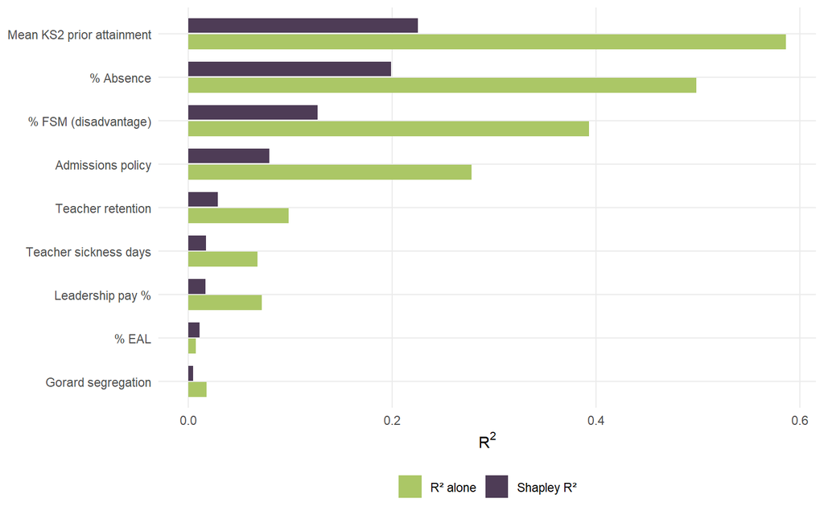

Figure 14: Explanatory power alone against the apportioned Shapley share, all nine predictors. Predictors whose ‘alone’ bar far exceeds their Shapley bar are those that borrow most heavily from the others.

```r
vd_shap9_tbl %>%
  mutate(Predictor = fct_reorder(Predictor, `Shapley R²`)) %>%
  pivot_longer(c(`R² alone`, `Shapley R²`), names_to = "Measure",
               values_to = "Value") %>%
  ggplot(aes(Value, Predictor, fill = Measure)) +
  geom_col(position = position_dodge(width = 0.75), width = 0.68) +
  scale_fill_manual(values = c("R² alone" = "#abc766",
                               "Shapley R²" = "#4e3c56")) +
  labs(x = expression(R^2), y = NULL, fill = NULL) +
  vd_theme + theme(legend.position = "bottom")
```

The Shapley values sum to 0.709, which is the $R^2$ of the full nine-predictor OLS model — the decomposition is exact, and distributes the whole of the explained variance without remainder.

### 16.4.6 By pupil group

The same decomposition, run separately on the disadvantaged and non-disadvantaged Attainment 8 outcomes. This requires school-years where all three outcomes are published, so the sample is slightly smaller.

```r
purrr::imap_dfr(vd_coh, \(ph, nm) tibble(
  Outcome = nm, Predictor = vd_lbl(VD_FOCAL),
  cell = sprintf("%.3f (%.1f%%)", as.numeric(ph), 100 * as.numeric(ph) / sum(ph))
)) %>%
  pivot_wider(names_from = Outcome, values_from = cell) %>%
  knitr::kable(align = "lrrr")
```

Table 9: Shapley (LMG) decomposition of the three-predictor model, separately by pupil group. Cells give the apportioned R-squared and, in brackets, its share of the three.

| Predictor | All pupils | Disadvantaged | Non-disadvantaged |
| --- | --- | --- | --- |
| % FSM (disadvantage) | 0.168 (22.3%) | 0.051 (8.6%) | 0.119 (17.3%) |
| % Absence | 0.278 (36.8%) | 0.297 (50.1%) | 0.251 (36.4%) |
| Mean KS2 prior attainment | 0.308 (40.9%) | 0.244 (41.2%) | 0.319 (46.3%) |

Absence and prior attainment change places between the two groups. For non-disadvantaged pupils prior attainment is comfortably the largest term; for disadvantaged pupils absence becomes the dominant one. Part of this is measurement — `ks2_c` is the mean KS2 score of the school’s whole intake, so it proxies the non-disadvantaged cohort’s starting point more closely than the disadvantaged cohort’s, and a cohort-specific measure would raise the disadvantaged prior-attainment figure. But the direction of the difference is what the attendance literature would predict: missed schooling costs disadvantaged pupils more, because they have less capacity to make up the lost ground outside school.

Disadvantage concentration ranks last of the three for every pupil group, as it does on every other measure in this section.

### 16.4.7 How much of the disadvantage association is compositional?

A school’s headline Attainment 8 is an average taken over its whole cohort, and is therefore, by construction, the weighted mean of its disadvantaged and non-disadvantaged pupils’ scores:

$$\text{ATT8} = w \cdot \text{ATT8}_{\text{disadv}} + (1 - w) \cdot \text{ATT8}_{\text{non-disadv}}$$

where $w$ is the school’s disadvantaged share. Raising $w$ shifts weight onto the lower-scoring group and pulls the average down *even if neither group’s score changes at all*. Part of the headline association between disadvantage and attainment is therefore mechanical — a property of how the measure is constructed rather than evidence about what schools do.

The size of that component can be estimated directly. Fixing both cohort scores at their sample means, so that schools differ only in composition and not at all in quality, and letting only $w$ vary reproduces an elasticity of -0.059 on log(% FSM) against the -0.207 actually observed — roughly 29% of the raw association.

```r
vd_dec %>%
  transmute(
    `Decile of % FSM` = dec,
    `Mean % FSM` = sprintf("%.1f", fsm),
    `Observed ATT8` = sprintf("%.1f", obs),
    `Composition-only ATT8` = sprintf("%.1f", cf),
    `ATT8 disadvantaged` = sprintf("%.1f", dis),
    `ATT8 non-disadvantaged` = sprintf("%.1f", non)
  ) %>%
  knitr::kable(align = "crrrrr")
```

Table 10: Observed Attainment 8 by decile of disadvantage, against what composition alone would produce if every school taught both groups equally well.

| Decile of % FSM | Mean % FSM | Observed ATT8 | Composition-only ATT8 | ATT8 disadvantaged | ATT8 non-disadvantaged |
| --- | --- | --- | --- | --- | --- |
| 1 | 7.9 | 61.5 | 49.5 | 50.4 | 62.5 |
| 2 | 12.9 | 52.5 | 48.9 | 40.1 | 54.3 |
| 3 | 16.3 | 50.0 | 48.5 | 38.4 | 52.3 |
| 4 | 19.5 | 48.3 | 48.1 | 37.6 | 50.9 |
| 5 | 22.8 | 46.5 | 47.7 | 36.6 | 49.4 |
| 6 | 26.6 | 45.1 | 47.3 | 36.2 | 48.3 |
| 7 | 30.8 | 44.0 | 46.8 | 36.2 | 47.5 |
| 8 | 35.8 | 43.3 | 46.2 | 36.5 | 47.0 |
| 9 | 42.9 | 41.9 | 45.3 | 36.3 | 46.1 |
| 10 | 56.3 | 40.9 | 43.7 | 37.0 | 45.9 |

Average Attainment 8 falls by 20.5 points between the least and most disadvantaged tenths of schools, of which 5.8 points would remain if every school in the country taught both groups equally well. The remainder is real — the last two columns show that both cohorts genuinely score lower in high-disadvantage schools — but it is considerably smaller than the raw figures imply.

One caveat on the table: the least-disadvantaged decile is unusual, in that disadvantaged pupils there average 50.4 points against 36.5 across the upper half of the distribution. That decile is dominated by selective and highly advantaged schools where the few disadvantaged pupils are unrepresentative, so the compositional share should be read as an average across the range rather than a constant.

### 16.4.8 What this section does and does not establish

**The importance ranking of the top two predictors is method-dependent.** By *t*-value absence leads; by explanatory power alone and by the Shapley decomposition prior attainment leads. The paper therefore reports *t*-values as measures of precision and does not use them to rank predictors.

**Prior attainment is large but is not a lever.** These measures rank explanatory power, not actionability. Prior attainment is the single largest source of variation on most of them, but it is fixed for any cohort already in secondary school. Once it is set aside as a description of intake, absence is the largest remaining factor open to intervention.

**None of this licenses a causal reading.** The relative-importance literature is explicit that these decompositions apportion *variance explained*, not *effect* (Grömping 2007). Two predictors can share variance because one causes the other, because a third thing causes both, or because they are alternative measurements of the same underlying disadvantage, and no decomposition of observational data can distinguish these. That prior attainment, absence and disadvantage overlap so heavily is itself the substantive finding: they are facets of a single structure, and the policy question is not which is most important but which of them can actually be moved.

### 16.4.9 References for this section

- Grömping, U. (2007) Relative importance for linear regression in R: the package `relaimpo`. *Journal of Statistical Software* 17(1), 1–27.
- Lindeman, R. H., Merenda, P. F. and Gold, R. Z. (1980) *Introduction to Bivariate and Multivariate Analysis*. Glenview, IL: Scott, Foresman.
- Shapley, L. S. (1953) A value for n-person games. In H. W. Kuhn and A. W. Tucker (eds) *Contributions to the Theory of Games, Volume II*. Princeton, NJ: Princeton University Press, 307–317.

## 16.5 Progress 8 as an independent route to the same answer

Two of this paper’s findings invite the same objection. We report that absence matters more for disadvantaged pupils than for others, and that once absence and prior attainment are held constant, disadvantaged pupils in higher-disadvantage schools do slightly *better*. In both cases a reader may reasonably say: your prior-attainment control is `ks2_c`, the mean KS2 score of the school’s whole intake, and a school-level average is a crude way to hold the *disadvantaged subgroup’s* starting point constant. If that control is inadequate, both findings could be artefacts of it.

The performance tables offer no direct remedy. Prior attainment is published only for the whole cohort — `KS2ASS`, `PTPRIORLO`, `PTPRIORAV` and `PTPRIORHI` in every year, with the underlying files carrying subject and qualification detail rather than intake — so a disadvantaged-specific version of the control cannot simply be substituted in.

Progress 8 gets at the question from a different direction. It is constructed by comparing each pupil with others *nationally who achieved the same KS2 result*, and it is published split by disadvantage (`P8MEA_FSM6CLA1A`, `P8MEA_NFSM6CLA1A`). The adjustment we are accused of making too crudely has therefore already been made, at pupil level, by someone else, using data we do not have.

This means the models below contain **no prior-attainment term at all**. Adding one would be a category error: `ks2_c` regressed on Progress 8 does not estimate the effect of prior attainment, since that has been removed from the outcome by construction. What such a coefficient would capture is the part of the school-level prior-attainment signal that the DfE’s national adjustment failed to remove — a diagnostic of the measure, not a finding about schools.

```r
p8_data <- imputed_full_data %>%
  filter(!is.na(ATT8SCR), ATT8SCR > 0,
         !is.na(ATT8SCR_FSM6CLA1A), ATT8SCR_FSM6CLA1A > 0,
         !is.na(ATT8SCR_NFSM6CLA1A), ATT8SCR_NFSM6CLA1A > 0,
         !is.na(P8MEA), !is.na(P8MEA_FSM6CLA1A), !is.na(P8MEA_NFSM6CLA1A),
         !is.na(ks2_c)) %>%
  droplevels()

P8_COH <- c("All pupils" = "P8MEA",
            "Disadvantaged" = "P8MEA_FSM6CLA1A",
            "Non-disadvantaged" = "P8MEA_NFSM6CLA1A")
A8_COH <- c("All pupils" = "ATT8SCR",
            "Disadvantaged" = "ATT8SCR_FSM6CLA1A",
            "Non-disadvantaged" = "ATT8SCR_NFSM6CLA1A")
```

### 16.5.1 How much prior attainment does Progress 8 actually remove?

Worth establishing before relying on it. If the pupil-level conditioning carried through perfectly to school level, a school’s Progress 8 would be uncorrelated with its mean KS2 intake.

```r
bind_rows(
  tibble(Outcome = paste("Progress 8 —", names(P8_COH)),
         r  = vapply(P8_COH, \(y) cor(p8_data[[y]], p8_data$ks2_c), numeric(1)),
         R2 = vapply(P8_COH, \(y) summary(lm(as.formula(paste(y, "~ ks2_c")),
                                             data = p8_data))$r.squared, numeric(1))),
  tibble(Outcome = "Attainment 8 — all pupils (for comparison)",
         r  = cor(log(p8_data$ATT8SCR), p8_data$ks2_c),
         R2 = summary(lm(log(ATT8SCR) ~ ks2_c, data = p8_data))$r.squared)
) %>%
  mutate(r = sprintf("%+.3f", r), R2 = sprintf("%.3f", R2)) %>%
  knitr::kable(align = "lrr", col.names = c("Outcome", "r with mean KS2", "R²"))
```

Table 11: Association between school mean KS2 and each outcome. Progress 8 removes most of the prior-attainment signal, but not all of it.

| Outcome | r with mean KS2 | R² |
| --- | --- | --- |
| Progress 8 — All pupils | +0.437 | 0.191 |
| Progress 8 — Disadvantaged | +0.319 | 0.101 |
| Progress 8 — Non-disadvantaged | +0.368 | 0.135 |
| Attainment 8 — all pupils (for comparison) | +0.788 | 0.621 |

Progress 8 removes roughly two-thirds of the prior-attainment signal but leaves a real residue: schools with higher-attaining intakes still post better Progress 8 scores. This is a known property of the measure rather than something peculiar to our sample, and it is the reason the check below is framed as corroboration from a different direction rather than as a definitive adjustment. It also means Progress 8 is not a clean value-added measure in its own right, which is part of why the paper does not use it as its main outcome.

### 16.5.2 Absence against Progress 8

```r
base_abs <- mean(p8_data$PERCTOT, na.rm = TRUE)

purrr::map_dfr(names(P8_COH), function(nm) {
  y <- P8_COH[[nm]]
  m <- lm(as.formula(paste(y, "~ log(PERCTOT)")), data = p8_data)
  s <- summary(m)
  b <- coef(m)[2]
  tibble(
    Cohort = nm,
    `R²` = sprintf("%.3f", s$r.squared),
    `t` = sprintf("%+.1f", s$coefficients[2, "t value"]),
    `Grades per subject from a 1pp cut in absence` =
      sprintf("%+.3f", b * (log(base_abs - 1) - log(base_abs)))
  )
}) %>%
  knitr::kable(align = "lrrr")
```

Table 12: Absence as the sole predictor of Progress 8. Progress 8 is measured in GCSE grades per subject, so the coefficients are directly interpretable.

| Cohort | R² | t | Grades per subject from a 1pp cut in absence |
| --- | --- | --- | --- |
| All pupils | 0.493 | -93.1 | +0.151 |
| Disadvantaged | 0.402 | -77.4 | +0.155 |
| Non-disadvantaged | 0.415 | -79.4 | +0.130 |

Two things follow. **Absence alone explains around half the variation in Progress 8** — after every pupil has been benchmarked against others who started in the same place. The objection that high-absence schools simply have weaker intakes does not survive this: the intake comparison has already been made, and absence remains the dominant single factor.

**A one percentage point reduction in absence is associated with roughly 0.15 of a GCSE grade in every subject**, from the sample mean absence rate of 9.1%. For a pupil entered for eight subjects that is somewhat over a grade in total. The association is around a sixth larger for disadvantaged pupils than for their peers, on a measure that has already equalised starting points — which is the attendance literature’s expectation, and the paper’s argument, arrived at independently.

### 16.5.3 The disadvantage coefficient, by two routes

```r
purrr::map_dfr(names(P8_COH), function(nm) {
  # Route 1: Attainment 8, controlling absence AND prior attainment
  m_a8 <- lm(as.formula(paste0("log(", A8_COH[[nm]],
                               ") ~ log(PTFSM6CLA1A) + log(PERCTOT) + ks2_c")),
             data = p8_data)
  # Route 2: Progress 8, controlling absence only
  m_p8 <- lm(as.formula(paste0(P8_COH[[nm]],
                               " ~ log(PTFSM6CLA1A) + log(PERCTOT)")),
             data = p8_data)
  tibble(
    Cohort = nm,
    `Att8: FSM coefficient` = sprintf("%+.3f", coef(m_a8)[["log(PTFSM6CLA1A)"]]),
    `Att8: t` = sprintf("%+.1f", summary(m_a8)$coefficients["log(PTFSM6CLA1A)", "t value"]),
    `P8: FSM coefficient` = sprintf("%+.3f", coef(m_p8)[["log(PTFSM6CLA1A)"]]),
    `P8: t` = sprintf("%+.1f", summary(m_p8)$coefficients["log(PTFSM6CLA1A)", "t value"])
  )
}) %>%
  knitr::kable(align = "lrrrr")
```

Table 13: The coefficient on log(% FSM) for each cohort, reached two ways. The Attainment 8 route controls prior attainment in the model; the Progress 8 route has it already in the outcome.

| Cohort | Att8: FSM coefficient | Att8: t | P8: FSM coefficient | P8: t |
| --- | --- | --- | --- | --- |
| All pupils | -0.047 | -21.2 | -0.131 | -18.1 |
| Disadvantaged | +0.083 | +23.6 | +0.111 | +12.3 |
| Non-disadvantaged | -0.007 | -3.4 | -0.038 | -5.2 |

The two routes share very little. One holds prior attainment constant as a school-level average inside the model; the other never mentions prior attainment, because the DfE has already conditioned on it pupil by pupil against national benchmarks. They nonetheless agree on the finding that has attracted most argument: **for disadvantaged pupils the coefficient on disadvantage concentration is positive under both**, and comfortably distinct from zero either way. For non-disadvantaged pupils it stays negative and small under both.

The contrast with Attainment 8 is instructive. There, controlling absence *alone* is not sufficient to produce the positive coefficient for disadvantaged pupils — prior attainment has to be in the model as well. Under Progress 8 it is not needed, because it is already in the outcome. The two specifications agree exactly where they should, and the objection that motivated this section — that a school-level average is too crude to hold the disadvantaged subgroup’s starting point constant — is answered by a specification that does not depend on that average at all.

### 16.5.4 Caveats

This runs on 8,914 school-years across three years. Progress 8 does not exist for 2024-25, for the reason set out in section 3.2, so this cannot replace the main analysis and is not intended to.

Progress 8 also embeds the DfE’s own modelling choices — its national benchmarking, its treatment of extreme scores, its handling of pupils without KS2 results — which we inherit rather than control. And as the first table shows, it is not fully intake-neutral. Corroboration from a measure with different assumptions is worth more than a second run of our own model, but it is corroboration, not proof.

The paper itself does not report any of this. It costs a year of data, and explaining Progress 8 properly would take a page the argument does not need. It is set down here so that the objection has an answer on the record.

· School Attainment Tool